# Acoustic Surveys Report for German Bank and Seal Island areas

### NASC Plots

NASC - Nautical Area Scattering Strength

Figure. Herring NASC’s by 2 nautical mile intervals during the 2020 Seal Island acoustic surveys.

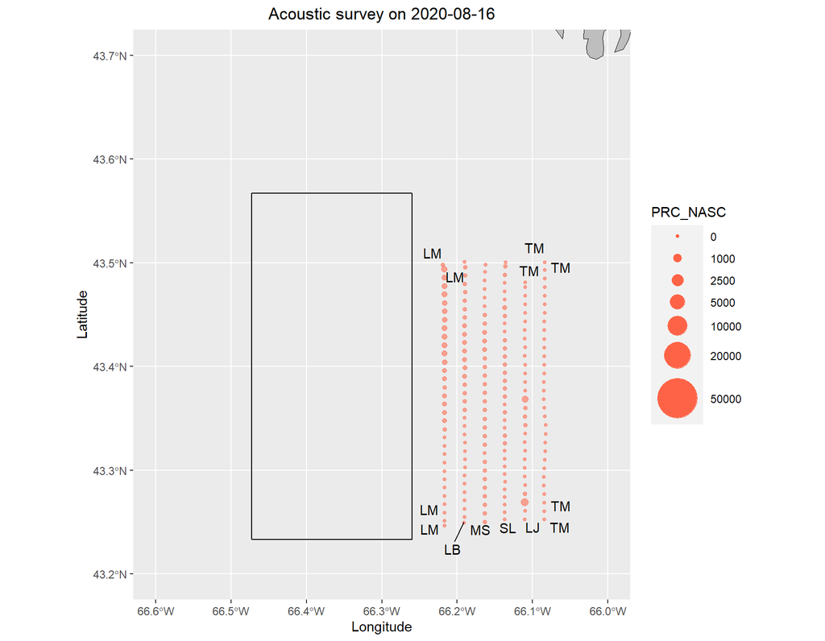

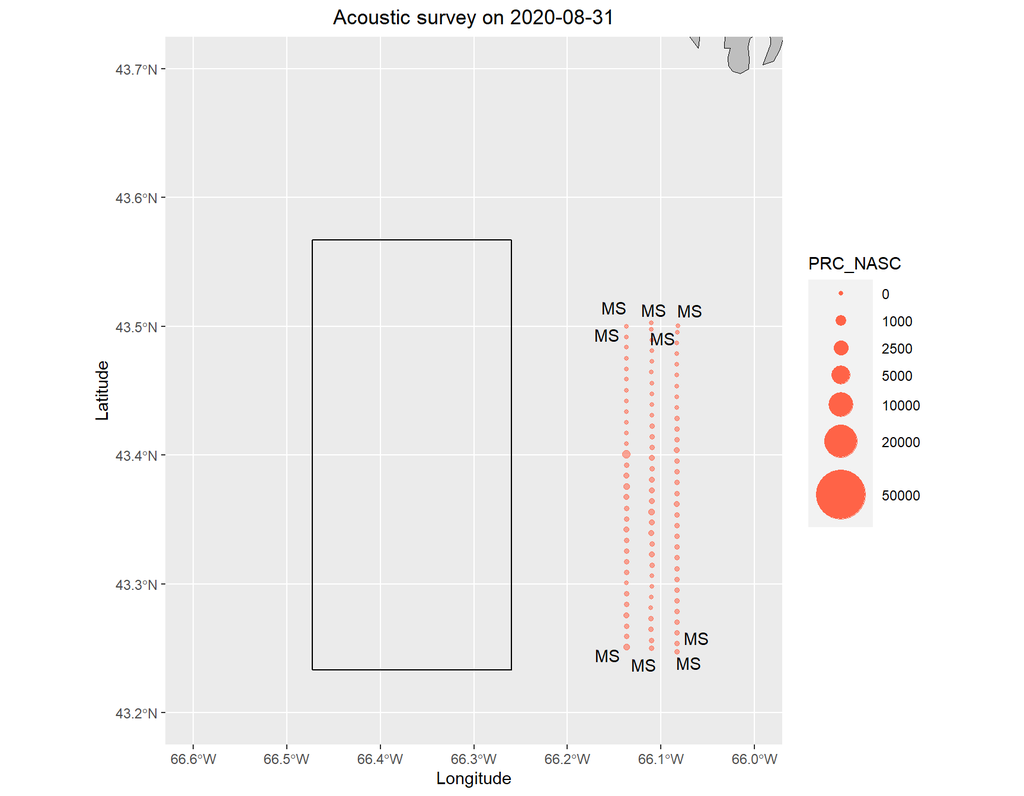

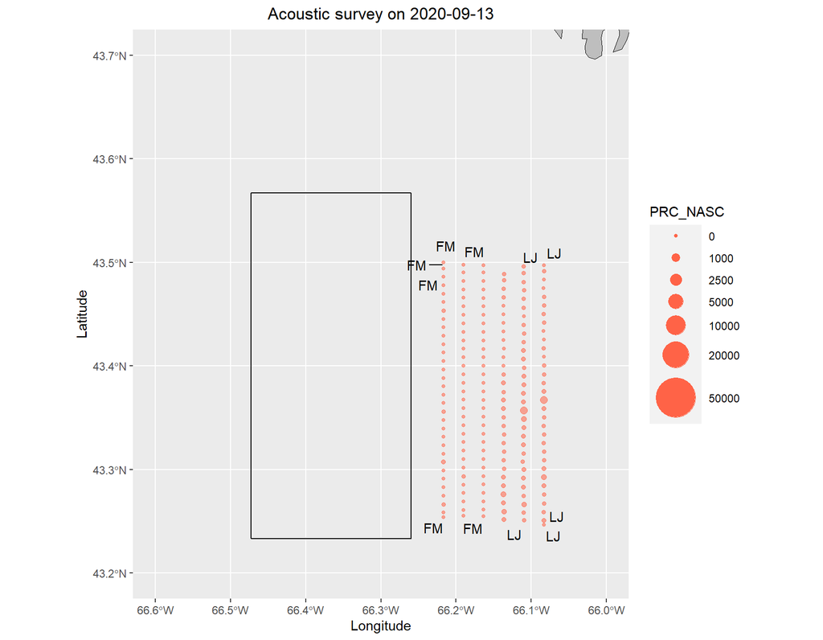

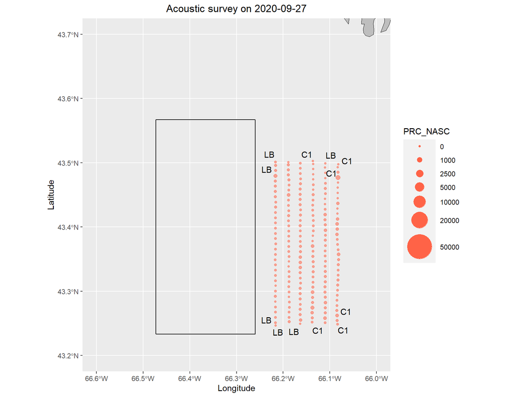

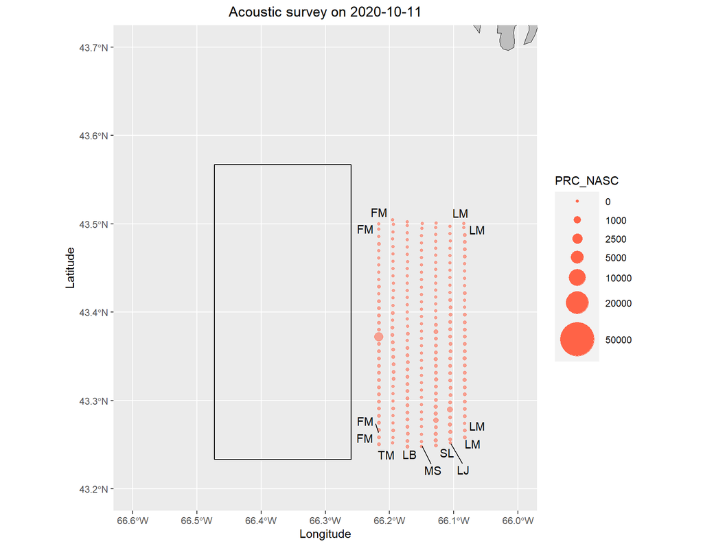

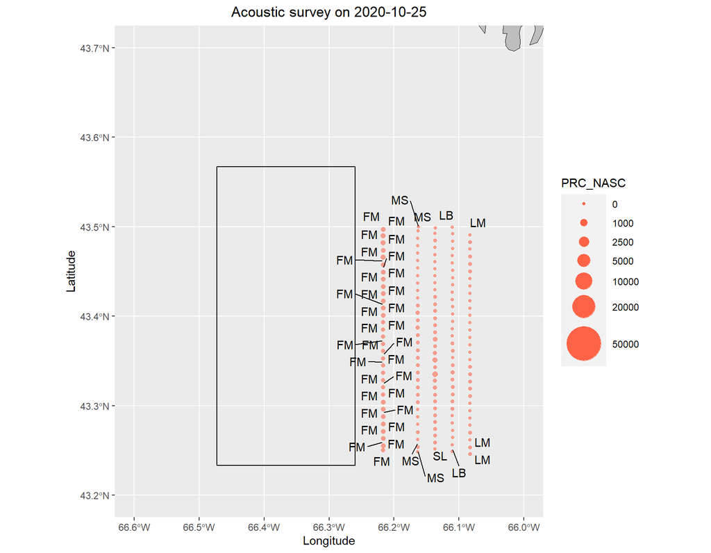

### SSB Bubble Plots

SSB - Spawning Stock Biomass

Figure. Spawning Stock Biomass (proportional to size of a bubble plot) in thousands Seal Island acoustic survey by day in the year. Note that SSB on this figure have not been adjusted by the turnover equations and neighboring survey times may be temporally auto-correlated.

Work in Progress - Years with missing Bubbles have not been added to the database.

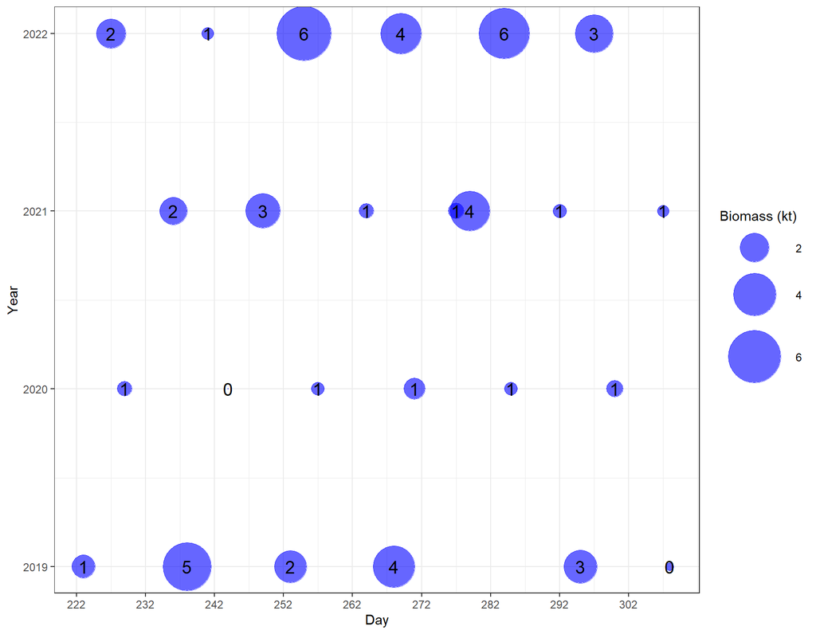

### Survey Details

[output not shown]

[output cut: 23 more lines]

| Location | Date | Transect Number | Target Strength (dB/kg) | Mean Sa (dB/m^2) | Distance (km) | Biomass Density kg/m^2 | Biomass (t) |
| --- | --- | --- | --- | --- | --- | --- | --- |
| SealIsland | 2020-08-16 | LB_T03 | -35.5000 | -71.6585 | 29.1632 | 0.0014 | 87.6757 |
| SealIsland | 2020-08-16 | LJ_T03 | -35.5000 | -68.6479 | 26.0172 | 0.0032 | 175.3628 |
| SealIsland | 2020-08-16 | LM_T03 | -35.5000 | -65.8476 | 28.8394 | 0.0055 | 334.1720 |
| SealIsland | 2020-08-16 | MS_T03 | -35.5000 | -73.0088 | 28.3805 | 0.0011 | 64.2468 |
| SealIsland | 2020-08-16 | SL_T03 | -35.5000 | -74.7272 | 30.5169 | 0.0007 | 43.2520 |
| SealIsland | 2020-08-16 | TM_T03 | -35.6073 | -83.1964 | 28.3646 | 0.0001 | 6.3070 |

| Location | Date | Transect Number | Target Strength (dB/kg) | Mean Sa (dB/m^2) | Distance (km) | Biomass Density kg/m^2 | Biomass (t) |
| --- | --- | --- | --- | --- | --- | --- | --- |
| SealIsland | 2020-08-31 | MS_T01 | -35.5 | -66.6580 | 28.5898 | 0.0023 | 143.9220 |
| SealIsland | 2020-08-31 | MS_T02 | -35.5 | -68.2401 | 28.4217 | 0.0016 | 99.9820 |
| SealIsland | 2020-08-31 | MS_T03 | -35.5 | -70.1833 | 28.4649 | 0.0010 | 63.9152 |

| Location | Date | Transect Number | Target Strength (dB/kg) | Mean Sa (dB/m^2) | Distance (km) | Biomass Density kg/m^2 | Biomass (t) |
| --- | --- | --- | --- | --- | --- | --- | --- |
| SealIsland | 2020-09-13 | FM_T01 | -35.5 | -78.6550 | 28.3249 | 0.0003 | 17.3446 |
| SealIsland | 2020-09-13 | FM_T02 | -35.5 | -87.2577 | 27.8958 | 0.0000 | 2.3927 |
| SealIsland | 2020-09-13 | FM_T03 | -35.5 | -Inf | 28.0209 | 0.0000 | 0.0000 |
| SealIsland | 2020-09-13 | LJ_T01 | -35.5 | -69.9480 | 27.0715 | 0.0022 | 128.7845 |
| SealIsland | 2020-09-13 | LJ_T02 | -35.5 | -67.1312 | 28.0483 | 0.0041 | 246.3460 |
| SealIsland | 2020-09-13 | LJ_T03 | -35.5 | -67.5560 | 28.1102 | 0.0037 | 223.3931 |

| Location | Date | Transect Number | Target Strength (dB/kg) | Mean Sa (dB/m^2) | Distance (km) | Biomass Density kg/m^2 | Biomass (t) |
| --- | --- | --- | --- | --- | --- | --- | --- |
| SealIsland | 2020-09-27 | C1_T03 | -35.5 | -70.4813 | 29.3398 | 0.0019 | 115.8611 |
| SealIsland | 2020-09-27 | C1_T02 | -35.5 | -67.7886 | 29.3725 | 0.0035 | 215.3830 |
| SealIsland | 2020-09-27 | C1_T01 | -35.5 | -66.0117 | 29.2226 | 0.0053 | 324.2600 |
| SealIsland | 2020-09-27 | LB_T03 | -35.5 | -69.1332 | 29.1200 | 0.0026 | 158.0317 |
| SealIsland | 2020-09-27 | LB_T02 | -35.5 | -68.0172 | 29.0441 | 0.0034 | 204.3370 |
| SealIsland | 2020-09-27 | LB_T01 | -35.5 | -68.2642 | 29.0366 | 0.0032 | 193.0420 |

| Location | Date | Transect Number | Target Strength (dB/kg) | Mean Sa (dB/m^2) | Distance (km) | Biomass Density kg/m^2 | Biomass (t) |
| --- | --- | --- | --- | --- | --- | --- | --- |
| SealIsland | 2020-10-11 | FM_T03 | -35.5000 | -66.3631 | 29.1321 | 0.0057 | 289.9657 |
| SealIsland | 2020-10-11 | LB_T03 | -35.5000 | -75.7057 | 29.2441 | 0.0007 | 33.7354 |
| SealIsland | 2020-10-11 | LJ_T03 | -35.5000 | -71.0278 | 27.8510 | 0.0020 | 99.0533 |
| SealIsland | 2020-10-11 | LM_T03 | -35.5000 | -73.1290 | 27.7554 | 0.0013 | 61.0593 |
| SealIsland | 2020-10-11 | MS_T03 | -35.5000 | -Inf | 28.3976 | 0.0000 | 0.0000 |
| SealIsland | 2020-10-11 | SL_T03 | -35.5000 | -70.4606 | 30.2112 | 0.0021 | 112.8745 |
| SealIsland | 2020-10-11 | TM_T03 | -35.6073 | -76.6193 | 28.4605 | 0.0006 | 28.0189 |

| Location | Date | Transect Number | Target Strength (dB/kg) | Mean Sa (dB/m^2) | Distance (km) | Biomass Density kg/m^2 | Biomass (t) |
| --- | --- | --- | --- | --- | --- | --- | --- |
| SealIsland | 2020-10-26 | FM_T03 | -35.5 | -63.9817 | 28.7805 | 0.0071 | 525.3623 |
| SealIsland | 2020-10-26 | LB_T03 | -35.5 | -75.8388 | 29.2864 | 0.0005 | 34.2572 |
| SealIsland | 2020-10-26 | LM_T03 | -35.5 | -75.0296 | 28.3840 | 0.0006 | 41.2730 |
| SealIsland | 2020-10-26 | MS_T03 | -35.5 | -72.6704 | 28.1768 | 0.0010 | 71.0531 |
| SealIsland | 2020-10-26 | SL_T03 | -35.5 | -68.5163 | 30.0287 | 0.0024 | 184.9273 |

### Notes

No additional notes for this area.

## About

This report was generated on: 2023-11-09 11:05:13  
dplyr R package version 1.1.2  
kableExtra R package version 1.3.4  
ggplot2 R package version 3.4.2  
dt R package version 0.28  
R version 4.2.0 Patched (2022-05-30 r82437 ucrt)